# Práctica 1

Author

Ágatha del Olmo Tirado, Luciana Ayoroa Cabrera

## Ejercicio 1

En este ejercicio analizamos la expansión de una mancha oscura en el mar a partir de datos obtenidos mediante fotografías tomadas desde un helicóptero. Vamos a modelar la evolución del área de la mancha utilizando una ecuación diferencial, que resolvemos tanto analítica como numéricamente con R. Esto nos permite predecir su crecimiento y estimar cuándo alcanzará un tamaño determinado, proporcionando información útil para la gestión de desastres ambientales.

Primero, cargamos las librerías necesarias para resolver y graficar. Además, definimos los datos del ejercicio. Los valores de S_inicial y S_10min representan el tamaño de la mancha al principio y después de 10 minutos según las fotografías.

```r
library(phaseR)
library(ggplot2)
library(dplyr)
library(hrbrthemes)

S_inicial <- c(1.047, 2.005, 3.348, 5.719, 7.273, 8.410, 9.117)  #tamaños iniciales
S_10min <- c(1.139, 2.087, 3.413, 5.765, 7.304, 8.426, 9.127)  #tamaños después de 10 min
observaciones <- c(1.047, 1.139, 2.005, 2.087, 3.348, 3.413, 5.719,
                   5.765, 7.273, 7.304, 8.410, 8.426, 9.117, 9.127)
t_interv <- 10  #intervalo de tiempo en minutos
```

Con estos datos, calculamos la tasa de cambio promedio de la mancha. Simplemente restamos los valores de S_10min de los valores de S_inicial y luego dividimos entre el intervalo de tiempo (en minutos), es decir, estamos calculando cómo cambia el tamaño de la mancha por minuto.

```r
dS_dt <- (S_10min - S_inicial) / t_interv #tasa de cambio promedia

datos <- data.frame(S_inicial, S_10min, dS_dt)
datos
```

```
  S_inicial S_10min  dS_dt
1     1.047   1.139 0.0092
2     2.005   2.087 0.0082
3     3.348   3.413 0.0065
4     5.719   5.765 0.0046
5     7.273   7.304 0.0031
6     8.410   8.426 0.0016
7     9.117   9.127 0.0010
```

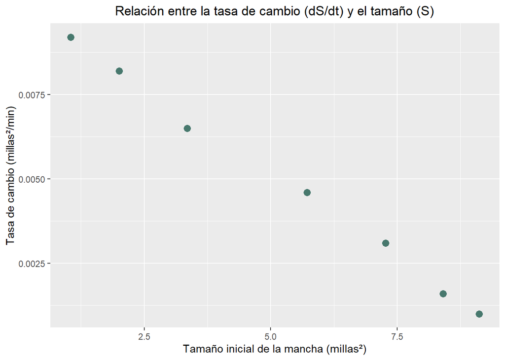

Los datos indican que la expansión de la mancha sigue un patrón de crecimiento rápido al inicio, pero con una desaceleración progresiva según crece la mancha (que en este caso es sinónimo a según pasa el tiempo). La ecuación diferencial que representa este comportamiento es una recta:

$\frac{dS}{dt}=aS+b$

Esta es una ecuación lineal en la que la tasa de cambio de la mancha depende del tamaño de la mancha. La pendiente de la recta está dada por $a$, y el término $b$, que es el intercepto en el eje $y$.

Por un lado, $a$ controla el crecimiento proporcional de la mancha. Es un parámetro relacionado con el ritmo de expansión de la mancha en función de su tamaño.

- Si $a>0$, el ritmo en que la mancha se acelera a medida que la mancha aumenta de tamaño.
- Si $a<0$, la tasa de crecimiento disminuye a medida que la mancha crece. En otras palabras, el área de la mancha sigue creciendo, pero a un ritmo cada vez más bajo.
- Si $a=0$, el ritmo de la expansión de la mancha sería constante y no dependería de su tamaño.

Por otro lado, $b$ representa que cuando el tamaño inicial de la mancha $S(0) = 0$, es decir, dando por hecho que la mancha empezó muy cercana a 0, la tasa de cambio de la mancha sería igual a $b$.

Para resolver la ecuación, debemos extraer los parámetros. Para hacerlo, partimos del hecho de que la relación sea lineal, y calculamos una recta que represente lo mejor la relación, y lo hacemos con el modelo de Regresión lineal simple (regresión lineal). La idea es que la suma de los residuos sea aproximadamente cero o lo más baja posible. Como el modelo seleccionado no es muy complejo, se generarán ciertos residuos, es decir, no esperamos que los resultados sean muy exactos.

```r
modelo_lineal <- lm(dS_dt ~ S_inicial, data = datos)
summary(modelo_lineal)
```

```
Call:
lm(formula = dS_dt ~ S_inicial, data = datos)

Residuals:
         1          2          3          4          5          6          7
 8.347e-05  4.230e-05 -3.135e-04  1.595e-04  2.149e-04 -1.471e-04 -3.952e-05

Coefficients:
              Estimate Std. Error t value Pr(>|t|)
(Intercept)  1.016e-02  1.554e-04   65.39 1.58e-08 ***
S_inicial   -1.001e-03  2.572e-05  -38.92 2.11e-07 ***
---
Signif. codes:  0 '***' 0.001 '**' 0.01 '*' 0.05 '.' 0.1 ' ' 1

Residual standard error: 0.0002009 on 5 degrees of freedom
Multiple R-squared:  0.9967,    Adjusted R-squared:  0.9961
F-statistic:  1515 on 1 and 5 DF,  p-value: 2.11e-07
```

Mirando los coeficientes, vemos que $a=-0.001$ y $b=0.01$.

Ahora podemos proceder a resolver la ecuación diferencial.

```r
source("flowField2.R") #cargamos el archivo "flowField2.R"
library(deSolve)

a <- modelo_lineal$coefficients[2]
b <- modelo_lineal$coefficients[1]

modelo <- function(time, vars, parms){
  with(as.list(c(vars, parms)), {
    dS = a*S+b
    return(list(dS))
  })
}
```

El proceso que seguimos para solucionar de forma analítica la función es la siguiente:

1. Separamos la t y la S

   $\frac{dS}{aS + b} = dt$
2. Integramos ambos lados

   $\int \frac{dS}{aS + b} = \int dt$
   - $\int \frac{dS}{aS + b} = \frac{1}{a}\ln|aS+b|$
   - $\int dt = t + C$

   $\frac{1}{a}\ln|aS+b| = t + C$
3. Despejamos la S

   $S = \frac{Ce^{ta}-b}{a}$
4. Resolvemos la $C$ sabiendo que $t=0$ y $S(0) = 1.047$ y conociendo los parámetros $a=-0.001$ y $b=0.01$

   $C = \frac{Sa+b}{e^{ta}} = 0.00912$

De esta forma obtenemos la solución explícita:

$S=\frac {0.00912e^{-0.001t}-0.01}{-0.001}$

Pero para resolverla numéricamente usamos R, tomando como la condición inicial el tamaño de la mancha en la primera fotografía tomada:

```r
parms <- c(a = a, b = b)
vars <- c(S = 1.047) #condición inicial

START <- 0
END <- 3000
STEP <- 10 #cada diez minutos
times <- seq(from = START, to = END, by = STEP)

#resolvemos la ecuación diferencial
sim <- ode(y = vars, times = times, parms = parms, func = modelo)

resdf <- as.data.frame(sim)

resdf$S_km2 <- resdf$S * 2.58999 #conversión de millas a km
head(resdf)
```

```
  time        S    S_km2
1    0 1.047000 2.711720
2   10 1.137711 2.946661
3   20 1.227518 3.179259
4   30 1.316433 3.409548
5   40 1.404460 3.637537
6   50 1.491611 3.863256
```

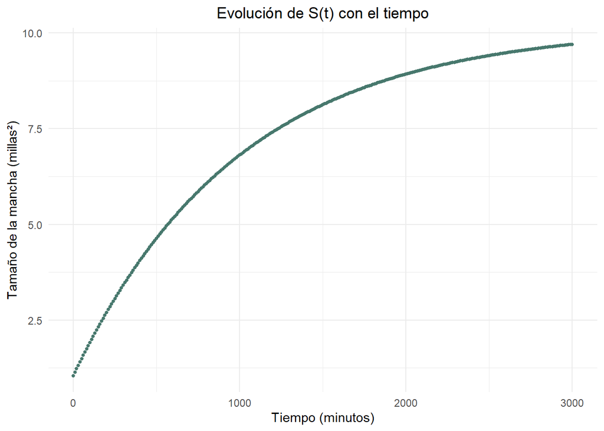

```r
ggplot() +
  geom_point(data = resdf, aes(x = time, y = S), color = "#47786D", size = 1) +
  labs(title = "Evolución de S(t) con el tiempo",
       x = "Tiempo (minutos)",
       y = "Tamaño de la mancha (millas²)") +
  theme_minimal() +
  theme(plot.title = element_text(hjust = 0.5))
```

**Ventana temporal**

Hemos escogido una ventana temporal lo suficientemente grande como para poder ver el efecto exponencial de decrecimiento, que con una $t<500$ es casi imperceptible dado el lento efecto de $e^{-0.001t}$.

Antes de analizar el gráfico, nos aseguramos de que nuestra solución analítica coincide con la numérica:

```r
C <- 1.047*a+b
S_t <- function(t, a, b, S0) {
  (C*exp(a*time)-b)/a
}

time <- seq(0, 3000, by = 10)

S_values <- S_t(time, a, b, 1.047)

df <- data.frame(time = time, Analítica = S_values, Numérica = resdf$S)
head(df)
```

```
  time Analítica Numérica
1    0  1.047000 1.047000
2   10  1.137711 1.137711
3   20  1.227518 1.227518
4   30  1.316431 1.316433
5   40  1.404458 1.404460
6   50  1.491609 1.491611
```

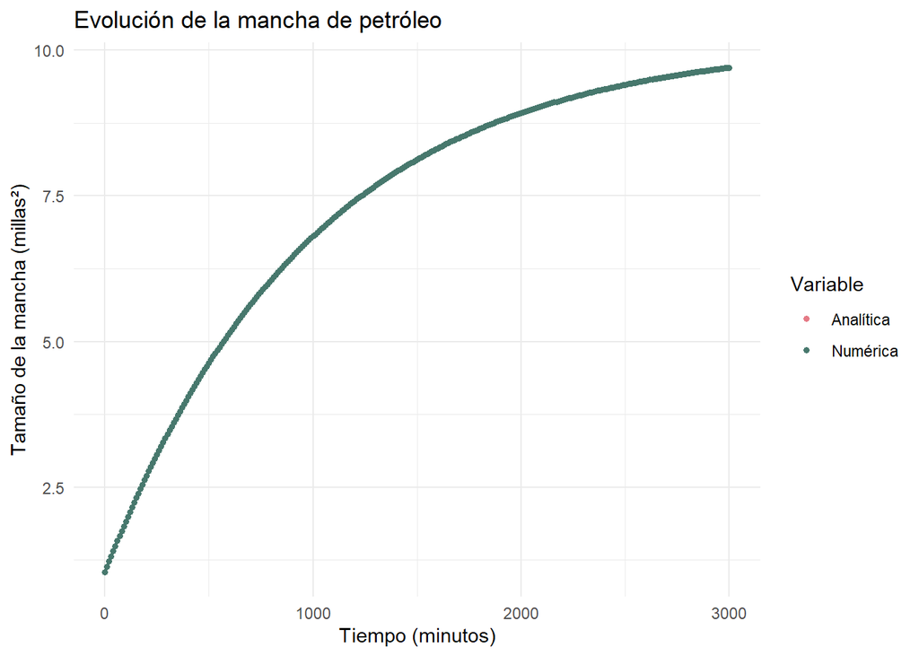

```r
ggplot(df, aes(x = time)) +
  geom_point(aes(y = Analítica, color = "Analítica"), size = 1.2) +
  geom_point(aes(y = Numérica, color = "Numérica"), size = 1.2) +
  scale_color_manual(values = c("Analítica" = "#e57a86", "Numérica" = "#47786D"),
                     name = "Variable",
                     labels = c("Analítica", "Numérica")) +
  labs(title = "Evolución de la mancha de petróleo",
       x = "Tiempo (minutos)",
       y = "Tamaño de la mancha (millas²)") +
  theme_minimal()
```

Como vemos, ambas soluciones coinciden perfectamente, además, observamos que $S(t)$ tiende a un número cercano a 10. Calculamos sustituyendo en la solución analítica $t \to \infty$ para ver a qué tamaño tiende S(t).

$S( \infty)=\frac {0.00912e^{-0.001 \infty}-0.01}{-0.001} = \frac {-0.01}{-0.001} = 10 millas^2$

En efecto, la mancha se quedará estancada en un tamaño de aproximadamente $10 millas^2$ o, lo que es lo mismo, $25.9 km^2$ con el tiempo.

Llevando a cabo el mismo proceso, podemos estimar el momento en que la mancha tendrá $S(t)$ tamaño, o qué tamaño tendrá en un momento $t$.

```r
S10 <- df %>% filter(time == 10)
S20 <- df %>% filter(time == 20)
S120 <- df %>% filter(time == 120)
```

```
Tamaño de la mancha a los 10 minutos: 1.138 millas², o 2.947 km²
```

```
Tamaño de la mancha a los 20 minutos: 1.228 millas², o 3.179 km²
```

```
Tamaño de la mancha a los 120 minutos: 2.078 millas², o 5.382 km²
```

```r
t8 <- df %>% filter(round(Analítica,2) == 8)

t1 <- df %>% filter(round(Numérica,2) == round(observaciones[1],2))
t3 <- df %>% filter(round(Numérica,2) == round(observaciones[3],2))
t5 <- df %>% filter(round(Numérica,2)== floor(observaciones[5]*100)/100)
t7 <- df %>% filter(round(Numérica,2) == round(observaciones[7],2))
```

Hemos redondeado hacia abajo en el caso de la quinta fotografía porque redondeando hacia arriba no encontraba ninguna coincidencia.

```
Momento en que la mancha mide 8 millas²: 1440
```

```
Momento de la primera fotografía con 1.047 millas²: 0
```

```
Momento de la tercera fotografía con 2.005 millas²: 110
```

```
Momento de la quinta fotografía con 3.348 millas²: 290
```

```
Momento de la séptima fotografía con 5.719 millas²: 720
```

## Ejercicio 2

En este ejercicio, analizamos la propagación de una epidemia de gripe en un internado inglés, utilizando un modelo basado en ecuaciones diferenciales que describe el comportamiento de la enfermedad en función de la cantidad de personas susceptibles, infectadas y recuperadas.

El objetivo es resolver el sistema de ecuaciones diferenciales para obtener respuestas sobre el tiempo necesario para alcanzar el pico de infecciones, la duración de la recuperación y por qué el número de infectados crece inicialmente rápido y luego disminuye. Además, se realiza una representación gráfica de la evolución de la enfermedad a lo largo del tiempo para ilustrar estos patrones.

Primero definimos los parámetros del modelo:

```r
beta  <- 2.18*10^(-3) #tasa de infección
gamma <- 0.44 #tasa de eliminación (recuperación)
```

- beta es la tasa de infección, que posiblemente indica la probabilidad de que un individuo susceptible se infecte por contacto con un infectado.
- gamma es la tasa de recuperación, que indica la velocidad con la que los infectados se recuperan.

De esta forma ya podemos montar la función de las tres ecuaciones mencionadas:

```r
parms = NULL

modelo_infeccion <- function(time, vars, parms){
  with(as.list(c(vars, parms)),{
    dS = -beta * S* I
    dI = beta * S* I - gamma*I
    dR = gamma*I
    return(list(c(dS, dI, dR)))
  })
}
```

Las ecuaciones son las siguientes:

- $\frac {dS}{dt} = -βSI$ → Los susceptibles disminuyen cuando entran en contacto con infectados porque pasan a estar infectados.
- $\frac {dI}{dt} = βSI - γI$ → Los infectados aumentan debido a nuevos contagios pero disminuyen cuando se recuperan.
- $\frac {dR}{dt} = γI$ → Los recuperados aumentan a medida que los infectados sanan.

Ahora resolvemos las ecuaciones diferenciales con los valores iniciales: S = 762 (personas susceptibles), I = 1 (infectado inicial) y R = 0 (ningún recuperado al inicio).

```r
parms <- c(gamma = gamma, beta = beta)
vars <- c(S = 762,
          I = 1,
          R = 0) #condición inicial

tiempo <- seq(0, 25, by = 1)

#resolvemos la ecuación diferencial
res <- ode(y = vars, times = tiempo, parms = parms, func = modelo_infeccion)

resdf <- as.data.frame(res)
head(resdf)
```

```
  time        S          I           R
1    0 762.0000   1.000000   0.0000000
2    1 758.7579   3.381525   0.8605872
3    2 747.9703  11.278954   3.7507596
4    3 713.8388  35.983483  13.1776702
5    4 620.9205 100.755171  41.3243688
6    5 444.2626 209.841346 108.8960492
```

Ahora podemos analizar los resultados que me ofrece.

Primero, buscamos el número máximo de infectados (pico de infección) y en qué día ocurre.

```r
pico_infeccion <- max(resdf$I)
```

```
El día del pico de infección es el número 6 con 287 personas infectadas.
```

Después, para descubrir el día en el que hay una completa recuperación, buscamos el momento en el que los infectados pasaron a ser 0 (o menores a 1 ya que son números enteros -personas-).

```r
t_menos1_inf <- resdf$time[resdf$I<1]
#elegimos la primera instancia, a partir de este momento sigue bajando
```

```
El día en que se consigue una completa recuperación es el número 23 .
```

Para encontrar este valor, nos da el primer día en el que la cantidad de infectados cae por debajo de 1.

Finalmente estudiamos de forma general el comportamiento de cada una de las variables realizando un gráfico:

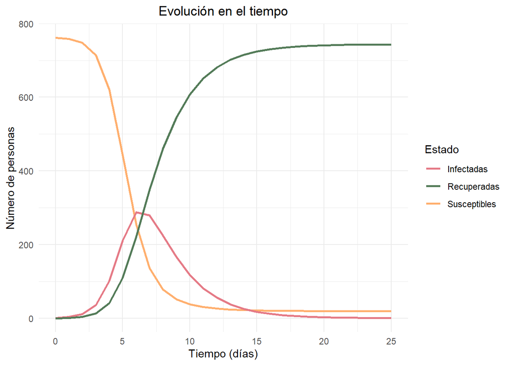

Inicialmente, hay muchas personas susceptibles (S) y pocos infectados (I). Como la infección se propaga a través del contacto entre susceptibles e infectados, el número de infectados crece rápidamente dada la beta, la tasa de infección (1 de cada 500 interacciones entre susceptible e infectado resulta en infección)

Sin embargo, a medida que más personas se infectan y se recuperan (R), quedan menos susceptibles disponibles para ser infectados (no se vuelven a infectar probablemente porque desarrollan anticuerpos), lo que reduce la tasa de nuevos contagios. Eventualmente, la cantidad de infectados comienza a disminuir porque la mayoría de la población ya se ha recuperado y por lo tanto el número de contactos entre infectados y susceptibles disminuye.